# 자분특HW6

## 자분특HW6 212STG25 이채영

```python
import numpy as np
import sklearn
from sklearn.model_selection import train_test_split
from sklearn.ensemble import RandomForestClassifier
from sklearn.ensemble import VotingClassifier
from sklearn.linear_model import LogisticRegression
from sklearn.svm import LinearSVC
from sklearn.metrics import accuracy_score
from sklearn.ensemble import BaggingClassifier
from sklearn.tree import DecisionTreeClassifier
from sklearn.ensemble import RandomForestClassifier
from sklearn.ensemble import AdaBoostClassifier
from sklearn.tree import DecisionTreeRegressor
from sklearn.ensemble import GradientBoostingRegressor
from sklearn.metrics import mean_squared_error
from sklearn.manifold import LocallyLinearEmbedding
from sklearn.manifold import TSNE
from sklearn.manifold import MDS
import matplotlib.pyplot as plt
import matplotlib.cm as cm
```

### #1

1. MNIST 자료를 이용하여 훈련세트 50000개, 검증세트 10000개, 테스트세트 10000개를 뽑은 후 랜덤포레스트, SVM 분류기 등 다양한 분류기를 훈련시킨 후 검증세트에서 개개인의 분류기보다 더 높은 성능을 내도록 분류기들을 간접 또는 직접 투표 방법을 사용해 앙상블로 연결해 보시오. 앙상블을 얻고 난 후에는 테스트 세트로 확인하여 개개인의 분류기와 비교하여 얼마나 성능이 향상되었는지를 파악해 보시오.

```python
from sklearn.datasets import fetch_openml

mnist = fetch_openml('mnist_784', version=1)
mnist.target = mnist.target.astype(np.uint8)
```

```python
# train, test 나누기
x_train, x_test, y_train, y_test=train_test_split(mnist.data, mnist.target, test_size=10000, random_state=42)

#train을 다시 train과 validation set로 나누기
x_train, x_val, y_train, y_val=train_test_split(x_train, y_train, test_size=10000, random_state=42)
```

```python
# randomforest, logisticregression, svm
ranfor=RandomForestClassifier(n_estimators=100, random_state=42)
dtree=DecisionTreeClassifier(max_depth=2,random_state=42)
#logreg=LogisticRegression(max_iter=3000,random_state=42)
svm=LinearSVC(random_state=42, max_iter=2000)
svm2=SVC(random_state=42)

for cand in (ranfor,dtree, svm, svm2):
    cand.fit(x_train, y_train)
    y_pred=cand.predict(x_val)
    print(cand.__class__.__name__, accuracy_score(y_val, y_pred))
```

```
RandomForestClassifier 0.9692
DecisionTreeClassifier 0.3416
```

```
LinearSVC 0.8649
SVC 0.9788
```

```python
# 투표기반 분류기
vote=VotingClassifier(
estimators=[('rf',ranfor),('dt',dtree),('svc',svm),('svm',svm2)], voting='hard')

vote.fit(x_train, y_train)

vote.score(x_val, y_val)
```

```
0.9507
```

```python
# 성능이 제일 낮은 분류기 제외시켜서 다시 돌려보기
vote.set_params(dt=None)
del vote.estimators_[1]

vote.score(x_val,y_val)
```

```
0.971
```

```python
#결정된 앙상블 테스트 데이터에서 성능 확인
vote.score(x_test,y_test)
```

```
0.9687
```

```python
#각 분류기에서의 성능
[ind.score(x_test, y_test) for ind in vote.estimators_]
```

```
[0.9645, 0.8634, 0.976]
```

- 앙상블에는 RandomForest, DecisionTree, LinearSVC, SVC 중 성능이 제일 낮은 DecisionTree를 제외한 RandomForest, LinearSVC, SVC를 이용하였다. 그 결과, DecisionTree를 제외하기 전에는 0.9507 제외한 뒤에는 0.971로 성능이 좋아진 것을 알 수 있다.
- test data set을 통해 앙상블과 각각의 분류기의 성능은 확인해 본 결과 앙상블의 경우 0.9687, 나머지 세 분류기는 각각 0.9645, 0.8634, 0.976이 나왔다.
- 전체적으로 SVC의 경우 개별 분류기가 더 좋게 나왔지만 나머지 두 개별 분류기보다는 앙상블이 성능이 더 좋아진 것을 알 수 있다.
- 다만, LinearSVC의 경우 max_iter를 2000으로 늘렸으나 수렴하지 못했다고 했으니 더 개선될 가능성은 있을 것으로 보인다.

### #2

MNIST 자료를 t-SNE, LLE, MDS를 적용하여 2차원으로 차원을 축소시킨 후 10개의 class를 각각 다른 색으로 나타낸 산점도를 그려 보시오.

```python
# dataset 나누기
x_train, x_test, y_train, y_test=train_test_split(mnist.data, mnist.target, test_size=5000, random_state=42)
```

```python
# t-SNE
tsne=TSNE(n_components=2, random_state=42)
x_tsne=tsne.fit_transform(x_test)

# LLE
lle=LocallyLinearEmbedding(n_components=2,n_neighbors=10)
x_lle=lle.fit_transform(x_test)

#MDS
mds=MDS(n_components=2, random_state=42)
x_mds=mds.fit_transform(x_test)
```

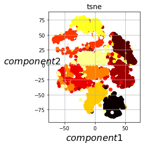

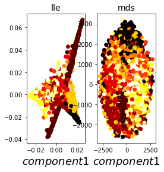

```python
titles = ["tsne", "lle", "mds"]
plt.figure(figsize=(11,4))
for subplot, title, x_pca in zip((131, 132, 133), titles,
                                     (x_tsne, x_lle, x_mds)):
    plt.subplot(subplot)
    plt.title(title, fontsize=14)
    plt.scatter(x_pca[:, 0], x_pca[:, 1], c=y_test,cmap=plt.cm.hot)
    plt.xlabel("$component1$", fontsize=18)
    if subplot == 131:
        plt.ylabel("$component2$", fontsize=18, rotation=0)
        plt.grid(True)
        plt.show()
```